# Econ 3110: Problem Set 7 - Solutions

## Question 1 (4 points)

Consider a monopsonist for whom the value of the marginal product of labour is $v(L) = 60 – L$. You can also interpret $v(L)$ as the labour demand function. The labour supply curve is given by: $$ L(w) = \begin{cases} w, & w \le 20 \\ 2w - 20, & w > 20 \end{cases} $$

### (a) (2 points) What is the monopsonist's optimal choice of labour ($L^*$)? What is the wage level ($w$*)?

**1. Find the inverse labor supply curve, $w(L)$:** We invert the piecewise labor supply function $L(w)$:

- If $w \le 20$, then $L = w$. This applies for $L \le 20$.
- If $w > 20$, then $L = 2w - 20 \implies L + 20 = 2w \implies w = \frac{L}{2} + 10$. This applies for $L > 20$.

So, the inverse supply curve is: $$ w(L) = \begin{cases} L, & L \le 20 \\ \frac{1}{2}L + 10, & L > 20 \end{cases} $$

**2. Calculate the total cost of labor, $C(L)$:** The total cost is $C(L) = w(L) \cdot L$. $$ C(L) = \begin{cases} L^2, & L \le 20 \\ \frac{1}{2}L^2 + 10L, & L > 20 \end{cases} $$

**3. Calculate the marginal cost of labor, $MC(L)$:** The marginal cost is the derivative of the total cost, $C'(L)$. $$ MC(L) = \begin{cases} 2L, & L \le 20 \\ L + 10, & L > 20 \end{cases} $$

**4. Apply the monopsonist's optimality condition:** The monopsonist chooses labor $L^*$ where the marginal cost of labor equals the value of the marginal product of labor (labor demand): $MC(L) = v(L)$. We check both segments:

- Case 1 ($L \le 20$): $2L = 60 - L \implies 3L = 60 \implies L = 20$. This is a potential solution as it falls within the defined range.
- Case 2 ($L > 20$): $L + 10 = 60 - L \implies 2L = 50 \implies L = 25$. This is also a potential solution.

To determine the optimum, we compare the monopsonist's profit, $\Pi(L) = R(L) - C(L)$, at these points. The revenue is the integral of the VMPL: $R(L) = \int_0^L (60-x)dx = 60L - \frac{1}{2}L^2$.

- $\Pi(20) = (60(20) - \frac{1}{2}(20)^2) - (20)^2 = 1200 - 200 - 400 = 600$.
- $\Pi(25) = (60(25) - \frac{1}{2}(25)^2) - (\frac{1}{2}(25)^2 + 10(25)) = 1500 - 312.5 - (312.5 + 250) = 1500 - 875 = 625$.

Profit is higher at $L=25$. Therefore, the optimal choice of labor is $L^* = 25$.

**5. Find the optimal wage, $w^*$:** The wage is determined by the labor supply curve at $L^*=25$. Since $25 > 20$, we use the second segment of the inverse supply curve: $$ w^* = w(25) = \frac{1}{2}(25) + 10 = 12.5 + 10 = 22.5 $$

The optimal choice is $L^*=25$ and $w^*=22.5$.

### (b) (2 points) Calculate the deadweight loss and illustrate it on a diagram.

**1. Find the competitive equilibrium ($L_c, w_c$):** The competitive equilibrium occurs where labor supply equals labor demand: $w(L) = v(L)$.

- Case 1 ($L \le 20$): $L = 60 - L \implies 2L = 60 \implies L = 30$. This contradicts the condition $L \le 20$.
- Case 2 ($L > 20$): $\frac{1}{2}L + 10 = 60 - L \implies \frac{3}{2}L = 50 \implies L_c = \frac{100}{3} \approx 33.33$. The wage is $w_c = 60 - \frac{100}{3} = \frac{80}{3} \approx 26.67$.

**2. Calculate the Deadweight Loss (DWL):** The DWL is the total surplus lost by moving from the competitive outcome ($L_c$) to the monopsony outcome ($L^*$). It is the area between the demand curve and the supply curve, from $L^*$ to $L_c$. $$ DWL = \int_{L^*}^{L_c} [v(L) - w(L)] dL $$ In the relevant range from $L^*=25$ to $L_c=100/3$, both $v(L)$ and $w(L)$ are in their second functional forms. $$ DWL = \int_{25}^{100/3} \left[(60 - L) - \left(\frac{1}{2}L + 10\right)\right] dL $$ $$ DWL = \int_{25}^{100/3} \left(50 - \frac{3}{2}L\right) dL $$ $$ DWL = \left[50L - \frac{3}{4}L^2\right]_{25}^{100/3} $$ $$ DWL = \left(50\frac{100}{3} - \frac{3}{4}\left(\frac{100}{3}\right)^2\right) - \left(50(25) - \frac{3}{4}(25)^2\right) $$ $$ DWL = \left(\frac{5000}{3} - \frac{3}{4}\frac{10000}{9}\right) - \left(1250 - \frac{1875}{4}\right) $$ $$ DWL = \left(\frac{5000}{3} - \frac{2500}{3}\right) - \left(\frac{5000-1875}{4}\right) = \frac{2500}{3} - \frac{3125}{4} = \frac{10000 - 9375}{12} = \frac{625}{12} \approx 52.08 $$

**3. Diagram:**

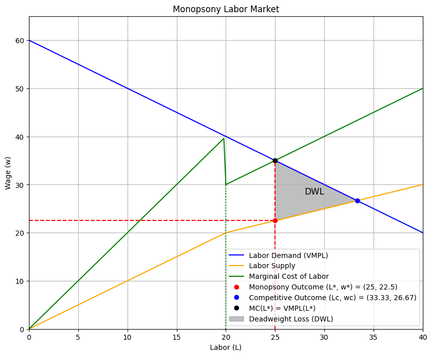

## Question 2 (8 points)

Having travelled back in time, you find yourself stranded in California during the early 1850s... The amount of gold (in tons) that can be obtained from a mine is $g = f(M)$, where $M$ is the number of miners and $f(·)$ is the known production function. Moreover, f is continuously differentiable and satisfies:

1. $f'(M) > 0$, $f''(M) < 0$ (it is strictly increasing and strictly concave)
2. $\lim_{M \to 0} f'(M) = \infty$ and $\lim_{M \to \infty} f'(M) = 0$ All gold that is mined is then distributed equally among miners. The unit price is $p$. Each miner can try to mine gold for a constant total cost $c > 0$.

### (a) (2 points) Assuming free entry of miners, derive the inverse supply curve $p_{FE}(g)$. Draw it on a diagram with g on the horizontal axis and p on the vertical axis. Prove that the curve slopes upwards.

**1. Free Entry Condition:** Miners will enter until the profit for a single miner is zero. The revenue for a miner is the price of gold $p$ times their share of the gold, $g/M$. The cost is $c$. $$ \text{Profit} = p \cdot \frac{g}{M} - c = 0 $$ Substituting $g = f(M)$, we get: $$ p \cdot \frac{f(M)}{M} = c \implies p = \frac{cM}{f(M)} $$

**2. Inverse Supply Curve $p_{FE}(g)$:** To express $p$ as a function of $g$, we use the fact that $f$ is invertible, so $M = f^{-1}(g)$, which we denote as $M(g)$. $$ p_{FE}(g) = \frac{c \cdot M(g)}{g} $$

**3. Prove the Curve Slopes Upwards:** We need to show that $\frac{dp_{FE}}{dg} > 0$. Using the quotient rule: $$ \frac{dp_{FE}}{dg} = c \cdot \frac{\frac{dM}{dg} \cdot g - M(g) \cdot 1}{g^2} $$ By the inverse function theorem, $\frac{dM}{dg} = \frac{1}{dg/dM} = \frac{1}{f'(M)}$. Substituting this in: $$ \frac{dp_{FE}}{dg} = \frac{c}{g^2} \left( \frac{g}{f'(M)} - M \right) = \frac{c}{g^2} \left( \frac{f(M)}{f'(M)} - M \right) $$ The sign of the derivative depends on the term in the parenthesis. Because $f(M)$ is strictly concave and we can assume $f(0)=0$, the average product $AP(M) = f(M)/M$ is always greater than the marginal product $MP(M) = f'(M)$. $$ \frac{f(M)}{M} > f'(M) \implies f(M) > M \cdot f'(M) \implies \frac{f(M)}{f'(M)} > M $$ Therefore, the term $\left( \frac{f(M)}{f'(M)} - M \right)$ is positive. Since $c > 0$ and $g^2 > 0$, we have $\frac{dp_{FE}}{dg} > 0$. The inverse supply curve slopes upwards.

**4. Diagram:** A simple sketch would show an upward-sloping curve from the origin in the $(g, p)$ space, labeled $p_{FE}(g)$.

### (b) (2 points) Derive the marginal cost curve. Draw it on your diagram from part (a), and interpret the relation between it and the inverse supply curve.

**1. Social Cost:** The total social cost of producing an amount of gold $g$ is the total cost of all miners, $M$. $$ C(g) = c \cdot M(g) = c \cdot f^{-1}(g) $$

**2. Marginal Cost (MC):** The marginal social cost is the derivative of the total social cost with respect to output $g$. $$ MC(g) = \frac{dC}{dg} = c \cdot \frac{dM}{dg} = c \cdot \frac{1}{f'(M)} $$

**3. Relation between MC and Inverse Supply:** Let's compare the two curves:

- Inverse Supply: $p_{FE}(g) = \frac{cM}{f(M)} = \frac{c}{f(M)/M} = \frac{c}{AP(M)}$
- Marginal Cost: $MC(g) = \frac{c}{f'(M)} = \frac{c}{MP(M)}$

As established before, due to the concavity of $f(M)$, the average product is greater than the marginal product ($AP(M) > MP(M)$). Therefore: $$ \frac{1}{AP(M)} < \frac{1}{MP(M)} \implies \frac{c}{AP(M)} < \frac{c}{MP(M)} $$ $$ p_{FE}(g) < MC(g) $$

**Interpretation:** The marginal social cost curve ($MC$) lies strictly above the inverse supply curve ($p_{FE}$). This represents a negative externality, a key feature of the "Tragedy of the Commons". When a new miner enters, they consider their private cost ($c$) and private benefit ($p \cdot g/M$). They do not account for the fact that their entry reduces the output for all existing miners (by lowering the average product $f(M)/M$). The supply curve reflects the private cost, while the MC curve reflects the true social cost. The gap between them is the externality.

**Diagram:** On the diagram from (a), draw another upward-sloping curve, $MC(g)$, that is everywhere above $p_{FE}(g)$.

### (c) (2 points) Suppose the demand curve for gold is $g_d(p) = 1/p$. Draw this on the same diagram as part (a) and identify the deadweight loss (shade the region).

**1. Inverse Demand:** The inverse demand curve is $p_d(g) = 1/g$.

**2. Equilibria:**

- **Free-Entry Equilibrium ($g_{FE}$):** Occurs where supply equals demand, $p_{FE}(g) = p_d(g)$. This is the market outcome.
- **Socially Optimal Equilibrium ($g^*$):** Occurs where marginal social cost equals demand, $MC(g) = p_d(g)$. This is the efficient outcome.

Because $MC(g) > p_{FE}(g)$, the free-entry equilibrium will have a higher quantity of gold produced than the social optimum ($g_{FE} > g^*$). At the free-entry output $g_{FE}$, the marginal social cost of the last unit is greater than its marginal benefit (the demand price), i.e., $MC(g_{FE}) > p_d(g_{FE})$.

**3. Deadweight Loss (DWL):** The deadweight loss is the loss in total social surplus due to overproduction. It is the area between the marginal social cost curve ($MC$) and the demand curve ($p_d$), integrated from the optimal quantity ($g^*$) to the market quantity ($g_{FE}$).

**Diagram:**

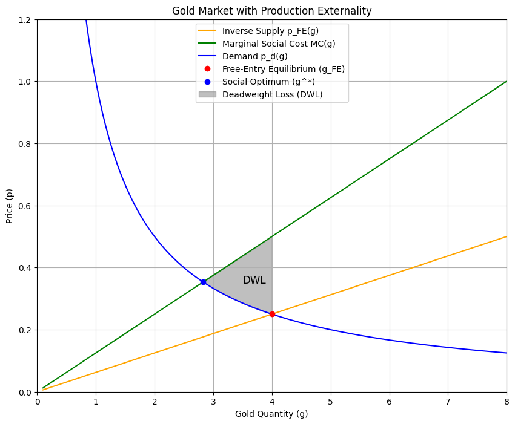

### (d) (2 points) Draw the per-unit tax or subsidy on gold that would eliminate the deadweight loss. Explain why this policy works (in at most four lines).

To eliminate the deadweight loss, we need to reduce the quantity of gold produced from the inefficiently high level $g_{FE}$ to the socially optimal level $g^*$. This requires a **per-unit tax** on gold, not a subsidy.

**Explanation:** The tax increases the private cost of production, shifting the private supply curve upwards. The optimal tax, $t$, should be set equal to the size of the externality at the efficient output level, $t = MC(g^*) - p_{FE}(g^*)$. This policy forces miners to internalize the negative externality they impose on others. By aligning the new private marginal cost with the social marginal cost, the tax guides the market to produce the socially efficient quantity of gold, thereby eliminating the deadweight loss.

## Question 3 (6 points)

You decide to operate a Poke Mart... consumers are located uniformly across the route with density one... at any distance $x \in [0, 1]$ from your store... If a consumer at distance $x$ visits the store, then her demand for the good is $q(x) = 1 − p$ and her net utility is $u(q(x)) = q(x) - \frac{[q(x)]^2}{2} - pq(x) – tx$...

### (a) (2 points) Suppose that only consumers with distance $x \le \bar{x}$ decide to visit the store. Derive $\bar{x}$ as a function of $p$ and $t$. Thus, write down your profit as a function of $p$ and $t$. Derive the profit-maximizing price $p^*$.

**1. Find Consumer Surplus and the Marginal Consumer $\bar{x}$:** First, let's find the utility (consumer surplus) a customer gets from purchasing the goods, *before* accounting for travel cost. Substitute $q = 1-p$ into the utility function: $$ U_{purchase} = (1-p) - \frac{(1-p)^2}{2} - p(1-p) $$ $$ U_{purchase} = (1-p)(1 - \frac{1-p}{2} - p) = (1-p)(\frac{2 - 1 + p - 2p}{2}) = (1-p)(\frac{1-p}{2}) = \frac{(1-p)^2}{2} $$ A consumer at distance $x$ visits if their net utility is non-negative: $U_{net} = U_{purchase} - tx \ge 0$. The marginal consumer, $\bar{x}$, is indifferent, so their net utility is exactly zero: $$ \frac{(1-p)^2}{2} - t\bar{x} = 0 \implies \bar{x} = \frac{(1-p)^2}{2t} $$

**2. Write Down the Profit Function:** All consumers from $x=0$ to $x=\bar{x}$ visit the store. Since density is one, the total number of customers is $\bar{x}$. Each customer buys $q = 1-p$ units. Marginal cost is zero. The total quantity sold is $Q = \bar{x} \cdot (1-p) = \frac{(1-p)^2}{2t} \cdot (1-p) = \frac{(1-p)^3}{2t}$. Profit, $\Pi$, is total revenue, $p \cdot Q$: $$ \Pi(p, t) = p \cdot \frac{(1-p)^3}{2t} $$

**3. Derive the Profit-Maximizing Price $p^*$:** We maximize profit with respect to $p$: $$ \frac{d\Pi}{dp} = \frac{1}{2t} \left[ 1 \cdot (1-p)^3 + p \cdot 3(1-p)^2(-1) \right] = 0 $$ $$ \frac{(1-p)^2}{2t} \left[ (1-p) - 3p \right] = 0 $$ $$ 1 - 4p = 0 \implies p^* = \frac{1}{4} $$

### (b) (2 points) Now suppose that you can set a two-part tariff with a fixed cost $F$ and a unit price of $p$. Find the optimal choices of $p$ and $F$.

With a two-part tariff and zero marginal cost, the optimal strategy is to set the per-unit price equal to marginal cost to maximize total surplus, and then use the fixed fee to extract that surplus.

**1. Optimal Price $p$:** Set the price equal to marginal cost: $p^* = 0$.

**2. Consumer Behavior at $p=0$:** At $p=0$, the consumer surplus from purchasing is $U_{purchase} = \frac{(1-0)^2}{2} = \frac{1}{2}$. A consumer will choose to visit and pay the fee $F$ if their net utility is non-negative: $$ U_{net} = U_{purchase} - F - tx = \frac{1}{2} - F - tx \ge 0 $$ The new marginal consumer, $\bar{x}$, is located where utility is zero: $$ \frac{1}{2} - F - t\bar{x} = 0 \implies \bar{x} = \frac{1/2 - F}{t} $$

**3. Profit Function and Optimal Fee $F$:** Profit comes entirely from the fixed fee $F$ paid by all $\bar{x}$ customers (since revenue from sales is $pQ = 0$). $$ \Pi(F) = \bar{x} \cdot F = \left(\frac{1/2 - F}{t}\right) F = \frac{1}{t}\left(\frac{F}{2} - F^2\right) $$ Maximize with respect to $F$: $$ \frac{d\Pi}{dF} = \frac{1}{t}\left(\frac{1}{2} - 2F\right) = 0 $$ $$ \frac{1}{2} - 2F = 0 \implies F^* = \frac{1}{4} $$

The optimal choices are $p^*=0$ and $F^*=1/4$.

### (c) (2 points) Write your profit from parts (a) and (b) as a function of $t$. Does the two-part tariff deliver a higher or lower profit? Explain the intuition.

**1. Compare Profits:**

- **Profit from (a) (single price):** $p^* = 1/4$. $$ \Pi_a = \frac{p^*(1-p^*)^3}{2t} = \frac{(1/4)(3/4)^3}{2t} = \frac{(1/4)(27/64)}{2t} = \frac{27}{512t} $$
- **Profit from (b) (two-part tariff):** $F^* = 1/4$. $$ \Pi_b = \frac{1}{t}\left(\frac{F^*}{2} - (F^*)^2\right) = \frac{1}{t}\left(\frac{1/4}{2} - (\frac{1}{4})^2\right) = \frac{1}{t}\left(\frac{1}{8} - \frac{1}{16}\right) = \frac{1}{16t} $$

To compare, we find a common denominator: $\frac{1}{16t} = \frac{32}{512t}$. Since $\frac{32}{512t} > \frac{27}{512t}$, the two-part tariff delivers a **higher profit**.

## Question 4 (12 points)

Consider a monopolist selling two goods, 0 and 1, both produced are zero marginal cost. Each consumer has a valuation $v_i$ for good $i \in \{0, 1\}$. The seller only knows that $v_0$ is uniformly distributed on $[0, 1]$ and $v_1$ is uniformly distributed on $[0, k]$, where $k \in (0, 1)$ is a known parameter.

### (a) (1 point) What price $p_i^*$ will the monopolist set for each good $i \in \{0, 1\}$?

The monopolist considers each market separately.

**For good 0:** Demand is $Q_0(p_0) = P(v_0 \ge p_0) = 1 - p_0$ for $p_0 \in [0,1]$. Profit is $\Pi_0(p_0) = p_0 Q_0 = p_0(1-p_0)$. $\frac{d\Pi_0}{dp_0} = 1 - 2p_0 = 0 \implies p_0^* = 1/2$.

**For good 1:** Demand is $Q_1(p_1) = P(v_1 \ge p_1) = 1 - p_1/k$ for $p_1 \in [0,k]$. Profit is $\Pi_1(p_1) = p_1 Q_1 = p_1(1-p_1/k)$. $\frac{d\Pi_1}{dp_1} = 1 - 2p_1/k = 0 \implies p_1^* = k/2$.

### (b) (2 points) Now suppose $v_1 = kv_0$. The seller first sets $p_0$, observes who buys, and can perfectly identify their $v_0$. The seller then sets a person-specific price for good 1 to each person who has bought good 0. What is the optimal person-specific price for good 1?

If a consumer with valuation $v_0$ buys good 0, the seller learns their exact $v_0$. Consequently, the seller also knows this consumer's valuation for good 1 is $v_1 = kv_0$. To maximize profit from this specific consumer for good 1, the seller will engage in perfect (first-degree) price discrimination and set a price that extracts all the consumer's surplus.

The optimal person-specific price for good 1 is $p_1(v_0) = v_1 = kv_0$.

### (c) (2 points) The seller also advertises a price to all consumers who have not bought good 0. If all consumers with valuations exceeding $\bar{v}_0$ for good 0 have bought good 0, what price $p_1^*$ will maximize the seller's profit from good 1?

The question states consumers with valuations exceeding $\bar{v}_0$ bought good 0. This implies the cutoff for buying good 0 is $\bar{v}_0$, which would be equal to the price, $p_0$. So, consumers who did *not* buy good 0 are those with $v_0 \in [0, p_0)$.

For this group, their valuation for good 1, $v_1 = kv_0$, is distributed on the interval $[0, kp_0)$. This is a uniform distribution.

The problem is identical to setting a monopoly price for a good with valuations uniformly distributed on $[0, K]$, where $K = kp_0$. From part (a), we know the optimal price in such a case is $K/2$.

Therefore, the optimal price for this group is $p_1^* = \frac{kp_0}{2}$.

### (d) (2 points) Suppose consumers are naive. Write down the seller's profit as a function of $p_0$ and explain each term.

The total profit $\Pi(p_0)$ has three components:

1. **Profit from selling good 0:** Consumers with $v_0 \in [p_0, 1]$ will buy good 0. The mass of these consumers is $(1-p_0)$. $$ \Pi_0 = p_0 (1-p_0) $$
2. **Profit from selling good 1 to good 0 buyers:** For each consumer who buys good 0 (with valuation $v_0 \in [p_0, 1]$), the seller sets a personalized price $p_1(v_0) = kv_0$. The profit is the sum (integral) of these prices. $$ \Pi_{1, \text{buyers}} = \int_{p_0}^{1} kv_0 \,dv_0 = k \left[\frac{v_0^2}{2}\right]_{p_0}^1 = \frac{k}{2}(1 - p_0^2) $$
3. **Profit from selling good 1 to good 0 non-buyers:** For consumers who do not buy good 0 ($v_0 \in [0, p_0)$), the seller sets a single price $p_1^* = kp_0/2$. A consumer in this group (with valuation $v_1 = kv_0$) will buy if $v_1 \ge p_1^*$, which means $kv_0 \ge kp_0/2 \implies v_0 \ge p_0/2$. So, the non-buyers of good 0 who *do* buy good 1 are those with $v_0 \in [p_0/2, p_0)$. The mass of these consumers is $(p_0 - p_0/2) = p_0/2$. $$ \Pi_{1, \text{non-buyers}} = \text{(mass of buyers)} \times \text{(price)} = \left(\frac{p_0}{2}\right) \left(\frac{kp_0}{2}\right) = \frac{kp_0^2}{4} $$

**Total Profit:** $$ \Pi(p_0) = \underbrace{p_0(1-p_0)}_{\text{Profit from Good 0}} + \underbrace{\frac{k}{2}(1 - p_0^2)}_{\text{Profit from Good 1, G0 Buyers}} + \underbrace{\frac{kp_0^2}{4}}_{\text{Profit from Good 1, G0 Non-buyers}} $$

### (e) (1 point) Solve part (d) to find the profit-maximizing price $p_0^{**}$?

First, we simplify the profit function: $$ \Pi(p_0) = p_0 - p_0^2 + \frac{k}{2} - \frac{k}{2}p_0^2 + \frac{k}{4}p_0^2 = p_0 - p_0^2(1 + \frac{k}{4}) + \frac{k}{2} $$ Now, we take the derivative with respect to $p_0$ and set it to zero: $$ \frac{d\Pi}{dp_0} = 1 - 2p_0(1 + \frac{k}{4}) = 0 $$ $$ 1 = 2p_0 \frac{4+k}{4} = p_0 \frac{4+k}{2} $$ $$ p_0^{**} = \frac{2}{4+k} $$

### (f) (2 points) Compare $p_0^{**}$ and $p_0^*$ from parts (a) and (e). Which is larger? How does an increase in $k$ affect $p_0^{**}$ and what is the economic intuition behind this?

**Comparison:**

- From (a), $p_0^* = 1/2$.
- From (e), $p_0^{**} = \frac{2}{4+k}$.

Since $k \in (0, 1)$, the denominator $4+k$ is strictly greater than 4. $$ 4+k > 4 \implies \frac{1}{4+k} < \frac{1}{4} \implies \frac{2}{4+k} < \frac{2}{4} = \frac{1}{2} $$ Therefore, $p_0^{**} < p_0^*$. The price of good 0 is lower when it is used as a screening device.

**Effect of $k$ on $p_0^{**}$:** $$ \frac{dp_0^{**}}{dk} = \frac{d}{dk} \left( \frac{2}{4+k} \right) = -\frac{2}{(4+k)^2} < 0 $$ An increase in $k$ causes $p_0^{**}$ to decrease.

**Economic Intuition:** The monopolist uses the sale of good 0 to learn about consumers' valuations for good 1. Lowering the price of good 0 brings more consumers into the market, allowing the monopolist to perfectly price discriminate on good 1 for a larger group. When $k$ is higher, good 1 is more valuable, making the information gained from selling good 0 even more profitable. This creates a stronger incentive to lower the price of good 0 to expand the base for these high-profit second sales.

### (g) (1 point) Suppose that consumers rationally anticipate the seller's incentives. Write down the condition for the marginal consumer (type $\hat{v}_0$) to be indifferent between buying good 0 and not buying it.

A rational consumer anticipates the pricing scheme for good 1 based on their decision for good 0.

1. **Utility if they buy good 0:** The consumer pays $p_0$ and gets utility $v_0 - p_0$. They anticipate that the seller will then know their $v_0$ and charge them $p_1 = v_1 = kv_0$ for good 1, leaving them with zero surplus from good 1. $$ U_{\text{buy}} = (v_0 - p_0) + (v_1 - p_1) = (v_0 - p_0) + 0 = v_0 - p_0 $$
2. **Utility if they do not buy good 0:** They are part of the non-buyer pool. They rationally anticipate the seller will set a single price for this group to maximize profit. This group consists of all consumers with valuations $[0, \hat{v}_0)$, where $\hat{v}_0$ is the marginal consumer. The seller will set the price $p_1^* = k\hat{v}_0/2$. The consumer will buy good 1 if their valuation $v_1=kv_0$ exceeds this price, getting surplus $kv_0 - k\hat{v}_0/2$. $$ U_{\text{not buy}} = \max(0, v_1 - p_1^*) = \max(0, kv_0 - k\hat{v}_0/2) $$

The marginal consumer, $\hat{v}_0$, is indifferent between these two options. At this margin, $v_0 = \hat{v}_0 > \hat{v}_0/2$, so the surplus from not buying is positive. $$ U_{\text{buy}}(\hat{v}_0) = U_{\text{not buy}}(\hat{v}_0) $$ $$ \hat{v}_0 - p_0 = k\hat{v}_0 - k\hat{v}_0/2 $$ $$ \hat{v}_0 - p_0 = \frac{k\hat{v}_0}{2} $$ This is the indifference condition.

### (h) (1 point) Write down the seller's profit as a function of $\hat{v}_0$ and $k$. Find the profit-maximizing level of $\hat{v}_0$ and use this to determine the optimal good-0 price $p_0^{***}$.

The seller chooses $p_0$, which in turn determines the marginal consumer $\hat{v}_0$. It is equivalent to say the seller chooses $\hat{v}_0$ directly.

**1. Express $p_0$ in terms of $\hat{v}_0$:** From the indifference condition in (g): $$ p_0 = \hat{v}_0 - \frac{k\hat{v}_0}{2} = \hat{v}_0\left(1 - \frac{k}{2}\right) $$

**2. Write profit as a function of $\hat{v}_0$:** The profit components are the same as in part (d), but the cutoff is now $\hat{v}_0$ instead of $p_0$.

- $\Pi_0 = p_0 (1 - \hat{v}_0) = \hat{v}_0(1 - k/2)(1 - \hat{v}_0)$.
- $\Pi_{1, \text{buyers}} = \int_{\hat{v}_0}^{1} kv_0 \,dv_0 = \frac{k}{2}(1 - \hat{v}_0^2)$.
- $\Pi_{1, \text{non-buyers}}$: Price is $p_1^* = k\hat{v}_0/2$. Buyers are those non-buyers of good 0 (i.e., $v_0 < \hat{v}_0$) for whom $v_0 \ge \hat{v}_0/2$. The mass of these consumers is $\hat{v}_0 - \hat{v}_0/2 = \hat{v}_0/2$. Profit is $(\text{mass}) \times (\text{price}) = (\hat{v}_0/2)(k\hat{v}_0/2) = \frac{k\hat{v}_0^2}{4}$.

Total Profit: $$ \Pi(\hat{v}_0) = \hat{v}_0(1 - k/2)(1 - \hat{v}_0) + \frac{k}{2}(1 - \hat{v}_0^2) + \frac{k\hat{v}_0^2}{4} $$ $$ \Pi(\hat{v}_0) = (1 - k/2)(\hat{v}_0 - \hat{v}_0^2) + \frac{k}{2} - \frac{k\hat{v}_0^2}{2} + \frac{k\hat{v}_0^2}{4} = (1 - k/2)\hat{v}_0 - (1 - k/2 + k/4)\hat{v}_0^2 + k/2 $$ $$ \Pi(\hat{v}_0) = (1 - k/2)\hat{v}_0 - (1 - k/4)\hat{v}_0^2 + k/2 $$

**3. Find optimal $\hat{v}_0$:** $$ \frac{d\Pi}{d\hat{v}_0} = (1 - k/2) - 2(1 - k/4)\hat{v}_0 = 0 $$ $$ (1 - k/2) = 2(1 - k/4)\hat{v}_0 = (2 - k/2)\hat{v}_0 $$ $$ \hat{v}_0^* = \frac{1 - k/2}{2 - k/2} = \frac{(2-k)/2}{(4-k)/2} = \frac{2-k}{4-k} $$

**4. Find optimal price $p_0^{***}$:** Substitute the optimal $\hat{v}_0^*$ back into the expression for $p_0$: $$ p_0^{***} = \hat{v}_0^* \left(1 - \frac{k}{2}\right) = \left(\frac{2-k}{4-k}\right) \left(\frac{2-k}{2}\right) = \frac{(2-k)^2}{2(4-k)} $$